# Explainable Multi-Hazard Disaster Prediction — the whole project, explained

**22AIE301 Probabilistic Reasoning**

| Team member | Roll number |
| --- | --- |
| Sai Reddy .A | CB.SC.U4AIE24205 |
| Rohit Vardhan .M | CB.SC.U4AIE24231 |
| Jithin Reddy .K | CB.SC.U4AIE24230 |
| Sai Vandith | CB.SC.U4AIE24239 |

Faculty: Dr. Navaneeth Haridasan · Amrita Vishwa Vidyapeetham, Coimbatore

### How to use this notebook

Read it from top to bottom. Every section explains one idea in plain English and then **runs the real project code** so you can see the actual numbers, not a description of them.

You do not need the internet. Everything here uses data already saved in the project folder.

To run it yourself: `Cell → Run All` in Jupyter. It takes about a minute.

### What you will understand by the end

1. What problem we are solving and why it is hard
2. What a Bayesian network is, built from scratch in 15 lines
3. Our actual model: 18 things we track and how they connect
4. Where the numbers inside the model come from
5. How we ask the model questions
6. How the system explains its own answer
7. How it decides what action to take
8. How we handle live weather data that is late, missing or disagreeing
9. What our results actually are, honestly

```python
# ---- setup: make the project importable and quieten warnings ----
import sys, json, warnings
from pathlib import Path

warnings.filterwarnings("ignore")

here = Path.cwd()
ROOT = here if (here / "src").exists() else here.parent
sys.path.insert(0, str(ROOT))

import pandas as pd
import numpy as np
import matplotlib.pyplot as plt
%matplotlib inline

pd.set_option("display.max_colwidth", 90)
print("project folder:", ROOT)
print("ready")
```

```
project folder: <repo root>
ready
```

## 1. The problem, and what our system does

Every year floods, landslides, cyclones and heat waves kill people in India. Warning systems already exist, but what a district officer actually receives is usually a colour or a yes/no. It does not say:

- **how likely** the disaster is,
- **why** the computer thinks so,
- **how sure** it is, given that half the sensors are usually broken,
- **what to actually do** about it.

Our system answers all four. Let us just run it and look.

```python
from src.engine import RiskEngine
from src.learn import load_model

# Load the model and ask it about one district on a bad monsoon day.
engine = RiskEngine(load_model())

today = {
    "Season": "Monsoon",
    "Rainfall": "Heavy",        # more than 64.5 mm in 24 hours
    "Humidity": "High",
    "RiverLevel": "High",       # at or past the danger mark
    "Slope": "Steep",           # a hill district
    "Urbanisation": "Low",
}

for hazard, p in engine.hazard_probabilities(today).items():
    print(f"{hazard:<11} {p:6.1%}")
```

```
Flood        80.8%
Landslide    92.8%
Cyclone      21.0%
Heatwave      0.6%
```

Four different disasters, **from the same evidence, at the same time**. A normal machine-learning model would need four separate models for this.

Now the second question: *why* does it say that?

```python
from src.explain import narrate

answer = narrate(engine, today, "Landslide")
print(answer["text"])
```

```
Landslide probability is 93% (High risk). The long-run base rate for this hazard is 9%. What pushed it up: steep hill slopes (x23.2 on the odds); very humid air (x1.4 on the odds); the river at or past its danger level (x1.2 on the odds). Our best reconstruction of what we cannot measure: already sa…
```

That paragraph is generated by the program. Nobody wrote those sentences by hand — the numbers in it (the odds multipliers, the counterfactual, the confidence) are all calculated.

And the fourth question: what should the officer *do*?

```python
from src.decision import recommend

plan = recommend(engine, today, population=1_100_000)   # Idukki district
print("Recommended action:", plan["action"])
print(plan["rationale"])
print()
for item in plan["checklist"]:
    print("  -", item)
```

```
Recommended action: Evacuate
P(rescue needed or hospital surge) = 91%. At that probability the maximum-expected-utility action is 'Evacuate' (EU -36.6 versus -47.1 for 'Prepare').

  - Evacuate low-lying and hillside settlements to the listed shelter
  - Close the affected highway / ghat stretch to traffic
  - Open relief camps and move stock of food and drinking water
  - Dispatch SDRF / NDRF teams with boats to the taluk headquarters
  - Put the district hospital and nearby PHCs on emergency standby
  - Stop all traffic on the ghat road and post barriers
  - Move hillside labour camps and tea-estate quarters first
```

## 2. What is a Bayesian network?

This is the single most important idea in the project, so let us build a tiny one from scratch before looking at the real one.

**In one sentence:** a Bayesian network is a picture of causes and effects, plus a small table of numbers for each arrow.

Our tiny example has three things:

```
Rain  ──►  WetSoil  ──►  Flood
```

Each arrow means *"this affects that"*. Each box needs a table saying **how strongly**. Those tables are called **CPTs** (conditional probability tables) — a CPT just answers "for each situation of the causes, how likely is the effect?"

```python
from pgmpy.models import DiscreteBayesianNetwork
from pgmpy.factors.discrete import TabularCPD
from pgmpy.inference import VariableElimination

tiny = DiscreteBayesianNetwork([("Rain", "WetSoil"), ("WetSoil", "Flood")])

# How often does it rain heavily at all?  (no causes, so just one column)
cpt_rain = TabularCPD("Rain", 2, [[0.8],      # no  heavy rain
                                  [0.2]],     # yes heavy rain
                      state_names={"Rain": ["no", "yes"]})

# If it rained, is the soil wet?   columns = Rain no / yes
cpt_soil = TabularCPD("WetSoil", 2, [[0.9, 0.3],    # dry
                                     [0.1, 0.7]],   # wet
                      evidence=["Rain"], evidence_card=[2],
                      state_names={"WetSoil": ["dry", "wet"], "Rain": ["no", "yes"]})

# If the soil is wet, is there a flood?  columns = WetSoil dry / wet
cpt_flood = TabularCPD("Flood", 2, [[0.99, 0.6],    # no flood
                                    [0.01, 0.4]],   # flood
                       evidence=["WetSoil"], evidence_card=[2],
                       state_names={"Flood": ["no", "yes"], "WetSoil": ["dry", "wet"]})

tiny.add_cpds(cpt_rain, cpt_soil, cpt_flood)
tiny.check_model()
print("tiny network is valid")
print(cpt_soil)
```

```
tiny network is valid
```

```
+--------------+----------+-----------+
| Rain         | Rain(no) | Rain(yes) |
+--------------+----------+-----------+
| WetSoil(dry) | 0.9      | 0.3       |
+--------------+----------+-----------+
| WetSoil(wet) | 0.1      | 0.7       |
+--------------+----------+-----------+
```

Read that table as: *if Rain = no, the soil is wet 10% of the time; if Rain = yes, the soil is wet 70% of the time.*

Now we can **ask it questions**. This is called *inference*.

```python
ask = VariableElimination(tiny)

def p_flood(evidence=None, label=""):
    r = ask.query(["Flood"], evidence=evidence, show_progress=False)
    p = float(r.values[list(r.state_names["Flood"]).index("yes")])
    print(f"{label:<38} P(flood) = {p:.1%}")

p_flood(None,                    "knowing nothing")
p_flood({"Rain": "yes"},         "after we learn it rained heavily")
p_flood({"WetSoil": "wet"},      "after we learn the soil is wet")
p_flood({"Rain": "no", "WetSoil": "wet"}, "soil wet but no rain (someone's canal?)")
```

```
knowing nothing                        P(flood) = 9.6%
after we learn it rained heavily       P(flood) = 28.3%
after we learn the soil is wet         P(flood) = 40.0%
soil wet but no rain (someone's canal?) P(flood) = 40.0%
```

Three things worth noticing, because our whole project is built on them:

**1. Evidence flows forwards.** Learning it rained raises the chance of a flood, even though rain does not touch Flood directly — it travels through WetSoil.

**2. Evidence also flows backwards.** We can reason from effect to cause, which a normal classifier cannot do:

```python
back = ask.query(["Rain"], evidence={"Flood": "yes"}, show_progress=False)
p_rain_given_flood = float(back.values[list(back.state_names["Rain"]).index("yes")])
print(f"P(it rained heavily)                 = 20.0%   (before we knew anything)")
print(f"P(it rained heavily | a flood happened) = {p_rain_given_flood:.1%}")
```

```
P(it rained heavily)                 = 20.0%   (before we knew anything)
P(it rained heavily | a flood happened) = 59.1%
```

**3. Once you know the middle, the start stops mattering.** Look at the last two lines of the earlier output: once we know the soil is wet, being told about the rain adds almost nothing. The soil "blocks" the path.

This has a name — **d-separation** — and it is why our explanations sometimes say *"the rainfall adds nothing once the other readings are known"*. That is not a bug; it is the network telling the truth.

## 3. Our real model

Same idea, just bigger: **18 things** we track, connected by **29 arrows**, arranged in five layers.

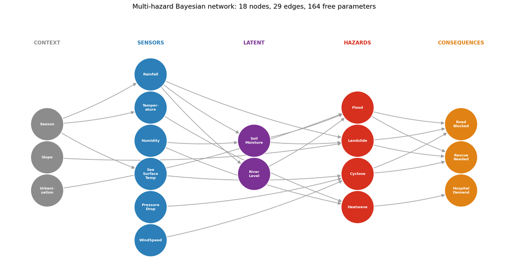

```python
from IPython.display import Image, display
from src.config import ARTIFACT_DIR

display(Image(str(ARTIFACT_DIR / "dag.png"), width=980))
```

Reading it left to right:

| Colour | Layer | Meaning |
| --- | --- | --- |
| Grey | Context | Things we already know: the season, the slope of the land, whether it is a city |
| Blue | Sensors | What we can measure: rain, temperature, humidity, wind, pressure, sea temperature |
| Purple | Hidden | Soil moisture and river level. **We usually cannot measure these**, so the model works them out |
| Red | Hazards | The four disasters |
| Orange | Consequences | What follows: roads blocked, rescue needed, hospitals busy |

The important design choice: flood, landslide and cyclone all point into the **same** orange boxes. A district runs *one* rescue operation, not three separate ones — so the model should combine them, not keep them apart.

```python
from src.networks import describe_model

info = describe_model(load_model())
for k, v in info.items():
    print(f"{k:>20} : {v:,}" if isinstance(v, (int, float)) else f"{k:>20} : {v}")
```

```
               nodes : 18
               edges : 29
     free_parameters : 164
     full_joint_size : 13,436,928
         compression : 81,932.5
```

That `compression` number is the whole reason we draw a graph.

If we tried to store one probability for **every possible combination** of all 18 things, we would need over 13 million numbers — and we would need far more data than exists to estimate them. By saying "this only depends on that", we get away with **164** numbers instead.

That is not a storage trick. It is what makes the model learnable at all.

```python
from src.config import STATES

pd.DataFrame(
    [(node, len(vals), ", ".join(vals)) for node, vals in STATES.items()],
    columns=["what we track", "how many values", "the values it can take"],
)
```

|  | what we track | how many values | the values it can take |
| --- | --- | --- | --- |
| 0 | Season | 3 | Winter, Summer, Monsoon |
| 1 | Slope | 3 | Flat, Moderate, Steep |
| 2 | Urbanisation | 2 | Low, High |
| 3 | Rainfall | 3 | Low, Moderate, Heavy |
| 4 | Temperature | 3 | Low, Normal, High |
| 5 | Humidity | 3 | Low, Medium, High |
| 6 | SeaSurfaceTemp | 2 | Normal, Warm |
| 7 | PressureDrop | 2 | No, Yes |
| 8 | WindSpeed | 4 | Calm, Breezy, Strong, Gale |
| 9 | SoilMoisture | 3 | Low, Medium, High |
| 10 | RiverLevel | 3 | Low, Medium, High |
| 11 | Flood | 2 | No, Yes |
| 12 | Landslide | 2 | No, Yes |
| 13 | Cyclone | 2 | No, Yes |
| 14 | Heatwave | 2 | No, Yes |
| 15 | RoadBlocked | 2 | No, Yes |
| 16 | RescueNeeded | 2 | No, Yes |
| 17 | HospitalDemand | 3 | Low, Medium, High |

Notice everything is in **bands**, not exact numbers. Rainfall is Low / Moderate / Heavy rather than 47.3 mm.

Why? Because the bands are the ones the India Meteorological Department actually uses (heavy rain = more than 64.5 mm in 24 hours), so the model speaks the same language as the people using it. The cost of this choice is measured later in section 9 — it is about 3 marks out of 100 in accuracy.

## 4. Where the numbers inside the model come from

Every arrow needs numbers. For example: *if the river is high and the soil is already wet, how likely is a flood?*

We did **not** type these one by one. The landslide table alone has 27 combinations, and if an examiner asked "why 0.63?" we would have no answer.

Instead we wrote a small formula with a few weights that a person can argue about, and let the computer fill in the full table. Here is a real one:

```python
model = load_model()
flood_cpt = model.get_cpds("Flood")

rows = []
for river in STATES["RiverLevel"]:
    for soil in STATES["SoilMoisture"]:
        rows.append({
            "river level": river,
            "soil": soil,
            "P(flood) in a village": round(flood_cpt.get_value(
                Flood="Yes", RiverLevel=river, SoilMoisture=soil,
                Urbanisation="Low"), 3),
            "P(flood) in a town": round(flood_cpt.get_value(
                Flood="Yes", RiverLevel=river, SoilMoisture=soil,
                Urbanisation="High"), 3),
        })
pd.DataFrame(rows)
```

|  | river level | soil | P(flood) in a village | P(flood) in a town |
| --- | --- | --- | --- | --- |
| 0 | Low | Low | 0.010 | 0.019 |
| 1 | Low | Medium | 0.071 | 0.144 |
| 2 | Low | High | 0.140 | 0.251 |
| 3 | Medium | Low | 0.091 | 0.231 |
| 4 | Medium | Medium | 0.303 | 0.498 |
| 5 | Medium | High | 0.494 | 0.680 |
| 6 | High | Low | 0.500 | 0.750 |
| 7 | High | Medium | 0.690 | 0.887 |
| 8 | High | High | 0.813 | 0.907 |

### The mistake we found in our own model

Our first landslide table was wrong, and it is worth showing because the computer never complained — the table was perfectly valid, our *thinking* was wrong.

```python
landslide = model.get_cpds("Landslide")

for rain, soil, slope, note in [
    ("Low",   "Low",  "Steep", "dry hill in January"),
    ("Heavy", "High", "Flat",  "flat land, soaked"),
    ("Heavy", "High", "Steep", "steep hill, soaked"),
]:
    p = landslide.get_value(Landslide="Yes", Rainfall=rain,
                            SoilMoisture=soil, Slope=slope)
    print(f"{note:<24} rain={rain:<6} soil={soil:<5} slope={slope:<6} -> {p:6.1%}")
```

```
dry hill in January      rain=Low    soil=Low   slope=Steep  ->   2.7%
flat land, soaked        rain=Heavy  soil=High  slope=Flat   ->   9.3%
steep hill, soaked       rain=Heavy  soil=High  slope=Steep  ->  94.1%
```

The first line is the point. Our original version gave a **dry** hill in January a 23% chance of a landslide, because we had written the formula so that a steep slope raised the risk *on its own*.

We also wrote a test so this mistake cannot come back: `tests/test_network.py::test_dry_steep_slope_is_safe_but_wet_steep_slope_is_not`

### Then we correct the numbers with data

Our elicited numbers are only a starting point. We then update them with data, using the standard rule:

> **start with what we believe → add what the data shows → the answer lands between the two**

If a situation appears thousands of times in the data, the data wins. If it almost never happens (gale-force wind is rare), our knowledge fills the gap instead of us trusting four noisy rows.

Here is how far the data moved each table — small bars mean our guess was already right:

```python
shift = pd.read_csv(ARTIFACT_DIR / "cpt_shift.csv")
shift[["node", "parents", "cells", "mean_abs_diff", "mean_kl"]].head(10)
```

|  | node | parents | cells | mean_abs_diff | mean_kl |
| --- | --- | --- | --- | --- | --- |
| 0 | RiverLevel | Rainfall, SoilMoisture | 9 | 0.2666 | 0.5775 |
| 1 | Humidity | Rainfall | 3 | 0.2719 | 0.4456 |
| 2 | WindSpeed | PressureDrop | 2 | 0.1413 | 0.2609 |
| 3 | Urbanisation | - | 1 | 0.2743 | 0.1554 |
| 4 | SoilMoisture | Rainfall, Humidity | 9 | 0.1194 | 0.1430 |
| 5 | Temperature | Season | 3 | 0.1178 | 0.1098 |
| 6 | HospitalDemand | RescueNeeded, Heatwave | 4 | 0.0864 | 0.0986 |
| 7 | Rainfall | Season | 3 | 0.0738 | 0.0557 |
| 8 | PressureDrop | SeaSurfaceTemp | 2 | 0.0983 | 0.0346 |
| 9 | Slope | - | 1 | 0.0665 | 0.0208 |

The two rows at the *bottom* of the full table are `RoadBlocked` and `RescueNeeded`, which barely moved at all (mean KL ≈ 0.002). Those were the tables we elicited by hand after reading reports of the 2018 Kerala floods — so that piece of guessing turned out to be accurate.

## 5. Asking the model questions

This is where a Bayesian network earns its keep. The same model answers many different questions — we do not retrain anything.

### Evidence arriving one piece at a time

```python
steps = [
    ({},                                                    "knowing nothing at all"),
    ({"Season": "Monsoon"},                                 "it is the monsoon"),
    ({"Season": "Monsoon", "Rainfall": "Heavy"},            "+ heavy rain today"),
    ({"Season": "Monsoon", "Rainfall": "Heavy",
      "RiverLevel": "High"},                                "+ river past danger mark"),
    ({"Season": "Monsoon", "Rainfall": "Heavy",
      "RiverLevel": "High", "Urbanisation": "High"},        "+ it is a built-up town"),
]

for evidence, label in steps:
    p = engine.probability("Flood", "Yes", evidence)
    print(f"{label:<32} P(flood) = {p:6.1%}")
```

```
knowing nothing at all           P(flood) =  16.2%
it is the monsoon                P(flood) =  32.5%
+ heavy rain today               P(flood) =  57.5%
+ river past danger mark         P(flood) =  86.4%
+ it is a built-up town          P(flood) =  90.4%
```

### Working out what we cannot measure

Almost no district has a soil-moisture probe. The model infers it instead:

```python
guess = engine.latent_map({"Season": "Monsoon", "Rainfall": "Heavy",
                           "Humidity": "High"})
print("Given heavy rain and humid air, the model believes:")
for node, value in guess.items():
    print(f"   {node:<14} = {value}")
```

```
Given heavy rain and humid air, the model believes:
   SoilMoisture   = High
   RiverLevel     = Medium
```

### The two independence facts we claim on our slides

We say these out loud in the review, so they are worth checking rather than trusting:

```python
print("Is rainfall related to flooding at all?          ",
      engine.is_dependent("Rainfall", "Flood", []))
print("Still, once we know the river and the soil?      ",
      engine.is_dependent("Rainfall", "Flood", ["RiverLevel", "SoilMoisture"]))
```

```
Is rainfall related to flooding at all?           True
Still, once we know the river and the soil?       False
```

`False` on the second line is d-separation again — exactly what we saw in the tiny network. Once we know the river level, the rainfall has nothing left to add.

### Explaining away

This one is more subtle, and examiners like it. Suppose we hear the road is blocked. That raises our suspicion of a flood. But if we then learn a landslide happened, the flood becomes *less* likely again — the landslide already explains the blocked road.

```python
p1 = engine.probability("Flood", "Yes", {"RoadBlocked": "Yes"})
p2 = engine.probability("Flood", "Yes", {"RoadBlocked": "Yes", "Landslide": "Yes"})

print(f"P(flood | road is blocked)                        = {p1:.1%}")
print(f"P(flood | road is blocked AND a landslide happened) = {p2:.1%}")
print()
print("The landslide 'explains away' the blocked road, so the flood becomes less likely.")
```

```
P(flood | road is blocked)                        = 54.8%
P(flood | road is blocked AND a landslide happened) = 46.5%

The landslide 'explains away' the blocked road, so the flood becomes less likely.
```

## 6. How the system explains itself

A probability alone is useless to someone who has to act at 2 a.m. So we answer four questions about every prediction — and all four are just more probability questions to the same network. We did **not** build a second program to explain the first one.

### Question 1: why is it high?

We take one reading away, ask the model again, and see how much the answer moves.

```python
from src.explain import evidence_attribution

table = evidence_attribution(engine, today, "Landslide")
pd.DataFrame(table)[["phrase", "direction", "odds_multiplier", "p_with", "p_without"]]
```

|  | phrase | direction | odds_multiplier | p_with | p_without |
| --- | --- | --- | --- | --- | --- |
| 0 | steep hill slopes | raises | 23.24 | 0.9276 | 0.3553 |
| 1 | very humid air | raises | 1.40 | 0.9276 | 0.9012 |
| 2 | the river at or past its danger level | raises | 1.25 | 0.9276 | 0.9113 |
| 3 | heavy rainfall (over 64.5 mm in 24 h) | neutral | 1.03 | 0.9276 | 0.9255 |
| 4 | the monsoon season | neutral | 1.00 | 0.9276 | 0.9276 |
| 5 | mostly rural drainage | neutral | 1.00 | 0.9276 | 0.9276 |

Read the top row: that reading multiplied the odds of a landslide by about 20. The `p_without` column is what we would have believed if that one reading had never arrived.

Notice some rows say **neutral**. That is d-separation showing up again — the reading was considered, but it adds nothing beyond what the others already say. We print it rather than hiding it, so the officer knows it was not ignored.

### Question 2: what if the weather had been kinder?

```python
from src.explain import counterfactuals

for c in counterfactuals(engine, today, "Landslide", top=2):
    print("-", c["sentence"])
```

```
- Had the humidity been low instead of high, the landslide probability would be 82% rather than 93%.
- Had the river level been low instead of high, the landslide probability would be 85% rather than 93%.
```

### Question 3: what should we measure next?

If we could send one person to read one gauge, which would help most? We measure this in **bits** — a bit is one yes/no question's worth of information.

```python
from src.explain import value_of_information

partial = {"Season": "Monsoon", "Rainfall": "Heavy"}     # not much known yet
voi = value_of_information(engine, partial, "Flood")
pd.DataFrame(voi)[["sensor", "expected_bits_gained"]].head(6)
```

|  | sensor | expected_bits_gained |
| --- | --- | --- |
| 0 | river gauge | 0.1186 |
| 1 | land-use record | 0.0180 |
| 2 | humidity sensor | 0.0019 |
| 3 | terrain record | 0.0000 |
| 4 | thermometer | 0.0000 |
| 5 | anemometer | 0.0000 |

The river gauge wins, which matches common sense — and that is the point. The system is not guessing; it computed which unknown is most tangled up with the answer.

## 7. How the system decides what to do

In our original abstract we wrote: *"if flood probability is above 80%, evacuate"*. We deleted that, and this section explains why.

A fixed number ignores two things that obviously matter: **how much an evacuation costs**, and **how bad it is if you do nothing and the disaster comes**.

So instead we give the computer a cost table and let it work out the threshold itself.

```python
from src.decision import (ACTIONS, ACTION_COST, HARM_IF_EMERGENCY,
                          FALSE_ALARM_COST, expected_utility, switch_points, evpi)

pd.DataFrame([{
    "action": a,
    "cost of doing it": ACTION_COST[a],
    "damage left if disaster comes": HARM_IF_EMERGENCY[a],
    "cost of a false alarm": FALSE_ALARM_COST[a],
} for a in ACTIONS])
```

|  | action | cost of doing it | damage left if disaster comes | cost of a false alarm |
| --- | --- | --- | --- | --- |
| 0 | Monitor | 0.0 | 100.0 | 0.0 |
| 1 | Advisory | 1.0 | 80.0 | 1.0 |
| 2 | Prepare | 6.0 | 45.0 | 2.0 |
| 3 | Evacuate | 25.0 | 12.0 | 8.0 |

Doing nothing is free but leaves 100 units of damage. Evacuating costs 25 but leaves only 12. There is also a real cost to crying wolf — people ignore the next warning.

Now: for each risk level, which action has the best expected outcome?

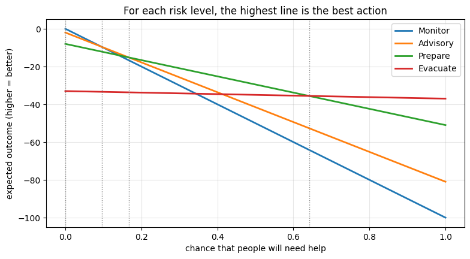

```
The computer works out these switching points by itself:
   Monitor   is best from  0.0% to  9.5%
   Advisory  is best from  9.6% to 16.7%
   Prepare   is best from 16.7% to 64.1%
   Evacuate  is best from 64.1% to 100.0%
```

```python
ps = np.linspace(0, 1, 201)

plt.figure(figsize=(9, 4.5))
for a in ACTIONS:
    plt.plot(ps, [expected_utility(a, p) for p in ps], linewidth=2, label=a)
for a, (lo, hi) in switch_points().items():
    plt.axvline(lo, color="grey", linestyle=":", linewidth=1)
plt.xlabel("chance that people will need help")
plt.ylabel("expected outcome (higher = better)")
plt.title("For each risk level, the highest line is the best action")
plt.legend()
plt.grid(alpha=0.3)
plt.show()

print("The computer works out these switching points by itself:")
for a, (lo, hi) in switch_points().items():
    print(f"   {a:<9} is best from {lo:5.1%} to {hi:5.1%}")
```

**This is the result we are proud of.** We never typed "0.64" anywhere. It came out of the cost table. If a district officer disagrees with our costs and changes them, the threshold moves automatically — which is exactly what should happen.

### What would a perfect forecast be worth?

There is one more useful number. If we could know the future exactly, how much better off would we be? That is called **EVPI**, and it tells us where spending money on a better sensor is actually worth it.

```python
print("chance of trouble  |  best action  |  value of a perfect forecast")
for p in (0.02, 0.10, 0.35, 0.50, 0.80, 0.98):
    best = max(ACTIONS, key=lambda a: expected_utility(a, p))
    print(f"      {p:5.0%}        |  {best:<9}   |   {evpi(p):5.2f}")
```

```
chance of trouble  |  best action  |  value of a perfect forecast
         2%        |  Monitor     |    1.26
        10%        |  Advisory    |    6.20
        35%        |  Prepare     |   10.10
        50%        |  Prepare     |   11.00
        80%        |  Evacuate    |    6.60
        98%        |  Evacuate    |    0.66
```

Notice it is near zero when the answer is obvious (2% or 98%) and largest in the middle, when we are genuinely unsure. So the model tells us *which districts are worth investing in* — the ones sitting on the fence.

## 8. Real live data, and the four methods we use on it

At our first review, sir gave us this feedback:

> *"It is mentioned real-time sensor data, but you are choosing the existing preprocessed data? Also, what methods are you incorporating to process the real-time data feed? It will be interesting to me."*

He was right — we were using data we had generated ourselves. This section is what we changed.

### Where the data comes from now

Three public services, no password needed:

| Service | What we get |
| --- | --- |
| Open-Meteo weather | rain, temperature, humidity, wind, air pressure — from **three independent forecast models** |
| Open-Meteo flood | how much water is flowing in the river (GloFAS) |
| Open-Meteo marine | sea temperature near the coast |

Here is one real saved pull:

```python
from src.feeds import SnapshotFeed, districts, SOURCE_LABEL

feed = SnapshotFeed()
all_districts = districts()
row = all_districts[all_districts["district"] == "Idukki"].iloc[0]
pull = feed.fetch_district(row)

print(f"district: {pull.district}    readings: {len(pull.observations)}")
pd.DataFrame([{
    "quantity": o.node,
    "value": o.value,
    "unit": o.unit,
    "who reported it": SOURCE_LABEL.get(o.source, o.source),
} for o in pull.observations]).head(12)
```

```
district: Idukki    readings: 16
```

|  | quantity | value | unit | who reported it |
| --- | --- | --- | --- | --- |
| 0 | Rainfall | 7.6 | mm/24h | GFS (NOAA) |
| 1 | Temperature | 25.1 | deg C | GFS (NOAA) |
| 2 | Humidity | 95.0 | % | GFS (NOAA) |
| 3 | WindSpeed | 12.4 | km/h | GFS (NOAA) |
| 4 | PressureDrop | 0.2 | hPa/24h | GFS (NOAA) |
| 5 | Rainfall | 12.1 | mm/24h | ECMWF IFS |
| 6 | Temperature | 25.5 | deg C | ECMWF IFS |
| 7 | Humidity | 96.7 | % | ECMWF IFS |
| 8 | WindSpeed | 15.5 | km/h | ECMWF IFS |
| 9 | PressureDrop | 1.4 | hPa/24h | ECMWF IFS |
| 10 | Rainfall | 1.5 | mm/24h | ICON (DWD) |
| 11 | Temperature | 25.8 | deg C | ICON (DWD) |

Look carefully at the three `Rainfall` rows: **the three weather services disagree with each other** about the same place and the same hour. That disagreement is not noise to be averaged away — it is information about how much to trust the reading. We use it in method 1 below.

### What using real data revealed

Fitting our model to real observations exposed a serious error in the version we presented at the first review.

```python
report = json.loads((ARTIFACT_DIR / "weather_relearn_report.json").read_text())

print(f"Learned from {report['rows_total']:,} real district-days "
      f"({report['window']})")
print()
print("P(rainfall band | it is the monsoon):")
comparison = pd.DataFrame({
    "our simulator said": report["monsoon_rainfall_simulated"],
    "the real data says": report["monsoon_rainfall_observed"],
})
display(comparison)

sim = report["monsoon_rainfall_simulated"]["Heavy"]
real = report["monsoon_rainfall_observed"]["Heavy"]
print(f"We believed {sim:.1%} of monsoon days were heavy rain.")
print(f"The truth is {real:.1%}  ->  we were about {sim/real:.0f} times too high.")
```

```
Learned from 35,072 real district-days (2019-01-01..2024-12-31)

P(rainfall band | it is the monsoon):
```

|  | our simulator said | the real data says |
| --- | --- | --- |
| Low | 0.0741 | 0.8368 |
| Moderate | 0.4987 | 0.1524 |
| Heavy | 0.4272 | 0.0108 |

```
We believed 42.7% of monsoon days were heavy rain.
The truth is 1.1%  ->  we were about 40 times too high.
```

This was **not a programming error**. The code was fine. Our understanding of Indian rainfall was wrong, and only real observations could show us that.

It had a real consequence too: because the model expected far more rain than actually falls, it started treating perfectly correct low-rainfall readings as suspicious. That taught us something important, which appears in method 3.

### Method 1 — a reading is not an exact fact

The India Meteorological Department calls rain below 15.6 mm "light" and above it "moderate". So what do we do with a reading of **15.0 mm**?

Forcing it into "light" throws away the fact that it is 0.6 mm from the boundary. Instead we keep both possibilities, weighted:

```python
from src.measurement import bin_likelihood
from src.config import STATES

def show(value, sigma, note):
    lik = bin_likelihood("rainfall_mm", value, sigma)
    parts = "   ".join(f"{s}={p:5.1%}" for s, p in zip(STATES["Rainfall"], lik))
    print(f"{note:<34} {parts}")

print("PROBLEM 1 - a reading sitting right on the 15.6 mm boundary:")
show(15.0, 3.0, "  15.0 mm, services agree")
print("   -> it refuses to pick a side, which is honest")
print()
print("PROBLEM 2 - the same reading, but the services disagree:")
show(30.0, 3.0, "  30 mm, services agree")
show(30.0, 25.0, "  30 mm, services disagree badly")
print("   -> confident when they agree, vague when they do not")
```

```
PROBLEM 1 - a reading sitting right on the 15.6 mm boundary:
  15.0 mm, services agree          Low=57.9%   Moderate=42.1%   Heavy= 0.0%
   -> it refuses to pick a side, which is honest

PROBLEM 2 - the same reading, but the services disagree:
  30 mm, services agree            Low= 0.0%   Moderate=100.0%   Heavy= 0.0%
  30 mm, services disagree badly   Low=28.2%   Moderate=63.4%   Heavy= 8.4%
   -> confident when they agree, vague when they do not
```

Two things to notice.

**Near a boundary, the reading splits its weight** across both bands instead of picking one. That is the honest thing to do.

**When the services disagree, the answer flattens out.** Look at the last two lines: the same 30 mm reading is a confident "Moderate" when the services agree, but spreads across all three bands when they do not. Nobody decides this by hand — the disagreement between the three forecast models *measures* how much to trust the reading. We calculate:

```
sigma = sqrt( instrument_error² + disagreement_between_services² )
```

Here is that happening on the real pull, for every quantity at once:

```python
from src.measurement import fuse_observations

fused = fuse_observations(pull.observations)
pd.DataFrame([{
    "quantity": node,
    "combined estimate": round(r.estimate, 2),
    "how many sources": r.n_sources,
    "how much they disagree": round(r.ensemble_spread, 2),
    "final uncertainty": round(r.sigma_effective, 2),
    "most likely band": r.most_likely_state(),
    "status": r.status,
} for node, r in sorted(fused.items())])
```

|  | quantity | combined estimate | how many sources | how much they disagree | final uncertainty | most likely band | status |
| --- | --- | --- | --- | --- | --- | --- | --- |
| 0 | Humidity | 94.30 | 3 | 2.82 | 5.74 | Low | stale |
| 1 | PressureDrop | 0.70 | 3 | 0.62 | 0.80 | No | stale |
| 2 | Rainfall | 7.07 | 3 | 5.32 | 6.11 | Low | stale |
| 3 | RiverLevel | 0.46 | 1 | 0.00 | 0.12 | Low | stale |
| 4 | Temperature | 25.47 | 3 | 0.35 | 1.06 | Low | stale |
| 5 | WindSpeed | 14.57 | 3 | 1.88 | 4.42 | Calm | stale |

### Method 2 — remembering the last few days

Our first model looked at one day at a time. But a flood is not caused by today's rain — it is caused by **three days of rain landing on ground that is already wet**.

So the system keeps a memory of how wet the soil is and how high the river is, and updates that memory each time new rain arrives. Let us watch it: three heavy days, then four dry ones.

```python
from src.temporal import HydrologyFilter

heavy = {"Low": 0.02, "Moderate": 0.10, "Heavy": 0.88}
dry   = {"Low": 0.90, "Moderate": 0.08, "Heavy": 0.02}

catchment = HydrologyFilter("demo")
history = [("start", catchment.marginals())]

for day, rain in enumerate([heavy] * 3 + [dry] * 4, start=1):
    catchment.step(rain)
    label = f"day {day} ({'heavy rain' if rain is heavy else 'dry'})"
    history.append((label, catchment.marginals()))

pd.DataFrame([{
    "": label,
    "chance soil is saturated": f"{m['SoilMoisture']['High']:.0%}",
    "chance river is dangerous": f"{m['RiverLevel']['High']:.0%}",
} for label, m in history])
```

|  |  | chance soil is saturated | chance river is dangerous |
| --- | --- | --- | --- |
| 0 | start | 13% | 4% |
| 1 | day 1 (heavy rain) | 33% | 12% |
| 2 | day 2 (heavy rain) | 48% | 20% |
| 3 | day 3 (heavy rain) | 56% | 26% |
| 4 | day 4 (dry) | 15% | 3% |
| 5 | day 5 (dry) | 7% | 1% |
| 6 | day 6 (dry) | 4% | 1% |
| 7 | day 7 (dry) | 3% | 1% |

This is a **dynamic Bayesian network** with the standard predict-then-update recursion, and it also fixed a weakness we had written down ourselves at the first review: *"our model has no memory"*.

### Methods 3 and 4 — trusting readings, and steady warnings

**Is this reading believable?** Before accepting a number, the system asks how surprising it is given everything else it knows. If it is very surprising we do **not** delete it — deleting data because the model dislikes it is exactly how you miss a real emergency. We keep it but trust it less.

> **The mistake we made here.** At first, when a reading looked strange we assumed the *sensor* was wrong. But once we plugged in real data, our *model* was the thing that was wrong (that 40× rainfall error), so it began rejecting perfectly good readings.

> Now we check first: if several independent services all agree and our model is still surprised, then the problem is our model. We keep the reading at full weight and flag the model for review.

**No flickering warnings.** The system recalculates constantly, so a district can sit right on the boundary between two actions and flip back and forth. An evacuation order that switches on and off is worse than either decision. So we raise the alert immediately, but only lower it after three calm readings in a row.

Let us run one complete real pass over a district and look at everything the system produces:

```python
from src.stream import StreamProcessor

processor = StreamProcessor("snapshot")     # replays the saved pull, no internet
record = processor.step(row, explain=True)  # 'row' is Idukki, from earlier

print("district :", record.district)
print("alert    :", record.alert_level, f"({record.hysteresis['reason']})")
print("confidence:", record.confidence["label"])
print()
for h, p in record.hazards.items():
    print(f"   {h:<11} {p:6.1%}")
print()
print(record.headline_explanation)
```

```
district : Idukki
alert    : Advisory (unchanged)
confidence: Medium

   Flood         3.4%
   Landslide     8.2%
   Cyclone       2.7%
   Heatwave      1.9%

Landslide probability is 8% (Low risk). The long-run base rate for this hazard is 4%. What pushed it up: steep hill slopes (x3.8 on the odds); the monsoon season (x1.2 on the odds). What is holding it down: the tracked catchment state (soil low, river low, carried forward from previous readings). Ou…
```

And this is what the system says it would like to measure next, in order:

```python
pd.DataFrame(record.polling_priority)[
    ["node", "expected_bits_gained", "have_reading", "status"]
]
```

|  | node | expected_bits_gained | have_reading | status |
| --- | --- | --- | --- | --- |
| 0 | SoilMoisture | 0.1291 | False | missing |
| 1 | Rainfall | 0.0645 | True | stale |
| 2 | Humidity | 0.0375 | True | stale |
| 3 | RiverLevel | 0.0131 | True | stale |
| 4 | Temperature | 0.0000 | True | stale |

## 9. Does it actually work? Our results, honestly

We tested on days the model had never seen. Two questions matter.

### Question 1: is it accurate when everything works?

```python
metrics = json.loads((ARTIFACT_DIR / "metrics.json").read_text())
from src.config import HAZARDS

scores = pd.DataFrame([{
    "model": name,
    "average score": round(sum(per[h]["auc"] for h in HAZARDS) / 4, 4),
} for name, per in metrics["comparison"].items()]).sort_values(
    "average score", ascending=False).reset_index(drop=True)
scores
```

|  | model | average score |
| --- | --- | --- |
| 0 | LogisticRegression | 0.9422 |
| 1 | GradientBoosting | 0.9399 |
| 2 | RandomForest | 0.9363 |
| 3 | BN-BDeu | 0.9144 |
| 4 | BN-Bayes (expert prior) | 0.9138 |
| 5 | BN-MLE | 0.9126 |
| 6 | BN-expert (no data) | 0.9082 |

**Be honest about this table.** Ordinary machine-learning models beat us by about 0.03 — roughly 3 marks out of 100. That is the price of putting readings into bands instead of using the exact numbers.

But look at the bottom row: our network with **no data at all**, using only the numbers we reasoned out by hand, already scores 0.908. That shows the elicitation was worth doing.

### Question 2: what happens when sensors break?

This is the question that actually matters, because in real districts the gauges are broken more often than not.

|  | 0% missing | 20% missing | 40% missing | 60% missing |
| --- | --- | --- | --- | --- |
| Our system | 0.891 | 0.883 | 0.875 | 0.863 |
| Ordinary model A | 0.912 | 0.883 | 0.837 | 0.789 |
| Ordinary model B | 0.901 | 0.886 | 0.861 | 0.812 |
| Ordinary model C | 0.908 | 0.888 | 0.861 | 0.791 |

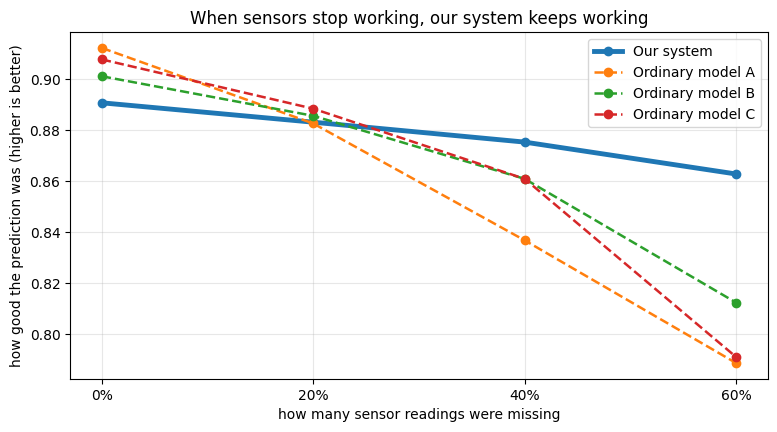

```python
study = metrics["missing_sensor_study"]
nice = {"BN-Bayes (expert prior)": "Our system",
        "LogisticRegression": "Ordinary model A",
        "RandomForest": "Ordinary model B",
        "GradientBoosting": "Ordinary model C"}

table = pd.DataFrame({
    nice.get(m, m): {rate: study[rate][m]["Flood"] for rate in study}
    for m in study["0%"]
}).T
table.columns = [f"{c} missing" for c in table.columns]
display(table.round(3))

plt.figure(figsize=(9, 4.5))
for m in study["0%"]:
    ys = [study[r][m]["Flood"] for r in study]
    ours = m.startswith("BN")
    plt.plot(list(study), ys, marker="o",
             linewidth=3.5 if ours else 1.8,
             linestyle="-" if ours else "--",
             label=nice.get(m, m))
plt.xlabel("how many sensor readings were missing")
plt.ylabel("how good the prediction was (higher is better)")
plt.title("When sensors stop working, our system keeps working")
plt.legend(); plt.grid(alpha=0.3)
plt.show()
```

**This is the main result of the project.**

The reason is simple, and it is the reason we chose a Bayesian network in the first place:

- Our model **leaves out** what it did not measure and works with the rest.
- An ordinary model **must** be given a number for every input, so it fills the gap with a guess — and a guess pretending to be a measurement is worse than an honest gap.

## 10. What is still not finished

We would rather say these ourselves than be caught:

- **The disaster part of the model is still not real data.** The weather layer is learned from 35,072 real district-days, but no public source lists verified flood and landslide dates per district, so that layer still uses our generated data. Building that list is the first job in our plan.
- **Band edges matter too much.** Two districts with 3.0 and 4.2 hPa of pressure drop get 11% and 37% cyclone risk, because 4.0 is a boundary. More bands would soften this.
- **The cost table is ours.** The method is sound but a real district officer should check the actual numbers.
- **On real monsoon data the system warns a bit too eagerly**, because the costs were tuned against our generated data. We are reporting this rather than quietly adjusting it to look better.
- **"People at risk" uses a flat 12% of the district population.** A real flood-plain map would be better.

### The plan

| Week | What we will do |
| --- | --- |
| 1–2 | Collect real flood and landslide dates for our districts |
| 3 | Train the disaster layer on that real data and re-run every result |
| 4 | Use several days of weather together, not one snapshot |
| 5–6 | Check the cost table with a real district officer |
| 7–8 | Package everything and write it up as a short paper |

## Glossary — every term we used, in one line each

| Term | In plain English |
| --- | --- |
| **Probability** | A number from 0 to 1 saying how likely something is |
| **Bayesian network** | A picture of causes and effects, plus a table of numbers for each arrow |
| **Node** | One thing we track, like rainfall or flood |
| **CPT** (conditional probability table) | For each situation of the causes, how likely is the effect |
| **Evidence** | The readings we actually have today |
| **Inference** | Working out an answer from the evidence |
| **Prior** | What we believed before seeing any data |
| **Posterior** | What we believe after seeing the evidence |
| **Latent / hidden** | Something we cannot measure, so the model works it out (soil moisture) |
| **Marginalising** | Correctly ignoring something we do not know, instead of guessing it |
| **d-separation** | Once you know the middle of a chain, the far end stops telling you anything new |
| **Explaining away** | One cause being confirmed makes a competing cause less likely |
| **MAP** | The single most likely explanation for what we observed |
| **Entropy** | How unsure the model is. High entropy = it does not know |
| **Bits** | The unit of information. One bit = one yes/no question answered |
| **Soft (virtual) evidence** | A reading entered as "probably this, possibly that" instead of a hard fact |
| **Ensemble** | Several independent forecasts of the same thing; their disagreement measures uncertainty |
| **Dynamic Bayesian network** | A Bayesian network that remembers yesterday |
| **Filtering** | Updating that memory as each new reading arrives |
| **Utility** | A number saying how good or bad an outcome is |
| **Expected utility** | The average outcome of an action, weighing each possibility by how likely it is |
| **EVPI** | How much a perfect forecast would be worth |
| **ROC-AUC** | A score from 0.5 (guessing) to 1.0 (perfect) for how well a model ranks risk |
| **Calibration** | Whether "70%" really happens 70% of the time |

## Where everything lives in the code

| File | What it does |
| --- | --- |
| `src/networks.py` | The picture: nodes, arrows, and the formulas that fill the tables |
| `src/engine.py` | Asking the model questions |
| `src/learn.py` | Correcting the numbers using data |
| `src/explain.py` | Turning an answer into sentences a person can read |
| `src/decision.py` | The cost table and choosing the action |
| `src/feeds.py` | Fetching live weather, river and sea data |
| `src/observed.py` | Six years of past weather, used to fix our numbers |
| `src/measurement.py` | Turning a messy reading into soft evidence |
| `src/temporal.py` | The memory of the last few days |
| `src/stream.py` | The full live pipeline, start to finish |
| `app/` | The website you can click on |
| `tests/` | 85 automated checks |

To see it running as a website: double-click `run.bat` and choose option **2**.